# Chicago R User Group: Pre-R/Finance Meetup

2018-05-30

## Local R News

## Chicago R User Group News

Leading up to this meetup, we reached **3170** members. As of yesterday’s close, that’s 90 new members since our last meetup.

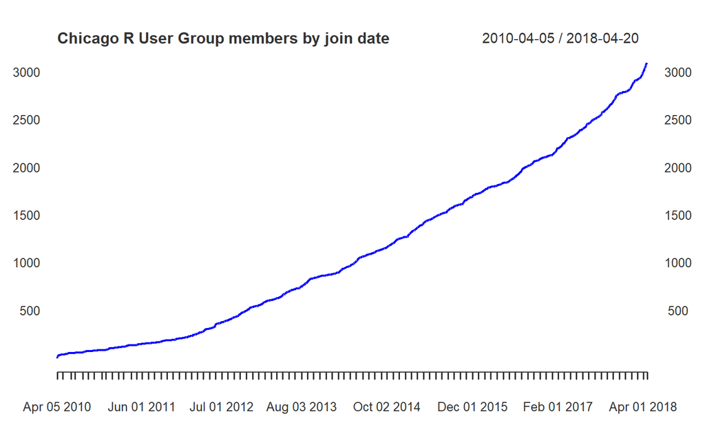

## Chicago R User Group

**RUGtools.** An R package containing data and functions to help us organize the Chicago R User Group.

`intro_slides`: Creates this slide template

`meetup_import`: Imports meetup data (but you need admin rights)

`member_list`: Data set of member list with PII removed

`pizza_estimate`: How many pizzas do we need for this here meetup?

`new_mem_counter`: How many members joined between each meetup.

You can download the package here:

```r
library(devtools)
install_github("Chicago-R-User-Group/RUGtools")
```

Want to contribute? Fork the repo from our Github page @Chicago-R-User-Group/RUGtools

Follow us:

[Chicago-R-User-Group](https://twitter.com/ChicagoRusers)

@ChicagoRusers

## R-Ladies Chicago

Thank you for attending! For more information, see their meetup page and twitter account:

[meetup.com/R-Ladies Chicago](https://www.meetup.com/rladies-chicago/)

@RLadiesChicago

## R Fortunes from the past

```r
library(fortunes)
fortune()
```

```
##
## I think that it's generally a good idea not to resist the most natural way
## of programming in R.
##    -- John Fox
##       R-help (March 2004)
```

## Jobs: Anyone hiring? Any Staffing Consultants?

C’mon…You know you want that risk-free referral bonus!

## Global R news

## R Consortium News: Spring Funding

[figure not shown]

Through the The Funded Project Program, now in it’s fourth year, the R Consortium has invested more that **$650,000** USD in over 30 projects that impact the over 2 million R users worldwide. Spring funding includes:

- Maintaining DBI: Kirill Müller
- Ongoing infrastructural development for R on Windows and MacOS: Jeroen Ooms
- Developing Tools and Templates for Teaching Materials: François Michonneau
- PSI application for collaboration to create online R package validation repository: Lyn Taylor
- A unified platform for missing values methods and workflows: Julie Josse and Nicholas Tierney
- histoRicalg — Preserving and Transfering Algorithmic Knowledge: John C Nash
- Proposal to Create an R Consortium Working Group Focused on US Census Data: Ari Lamstein

@[RConsortium](https://twitter.com/Rconsortium)

## Today’s meetup and its Sponsor

## Thanks to IBM!

[figure not shown]

## R/Finance: June 1st-2nd at UIC

[figure not shown]

From the inaugural conference in 2009, the annual R/Finance conference in Chicago has become the primary meeting for academics and practitioners interested in using R in Finance. Participants from academia and industry mingle for two days to exchange ideas about current research, best practices and applications.

https://www.rinfinance.com/

## Today’s Lightning Round contestants!

- **Ray Buhr**: Time Series graphing in practice
- **Troy Hernandez**: Simulating March Madness in R
- **Ross Bennett**: Predictive models and their applications in “high-ish” frequency finance.
- **Joe Rickert**: Package Watching
- **Dale Rosenthal**: Preview of “A Quantitative Primer on Investments with R.”